# Duration of *must* in spoken American English

### Duration & emphasis

Word duration can also be affected by whether a word is particularly emphasized - if you put emphasis in your speech, it’ll likely become more careful and thus of longer duration.

The descriptive statistic here shows that deontic *must* is not only more frequent, but also relatively more often with particular emphasis. Both properties, especially the frequency of occurrence, are *likely* due to the nature of the source data: the data is from US network television, which is more formal.

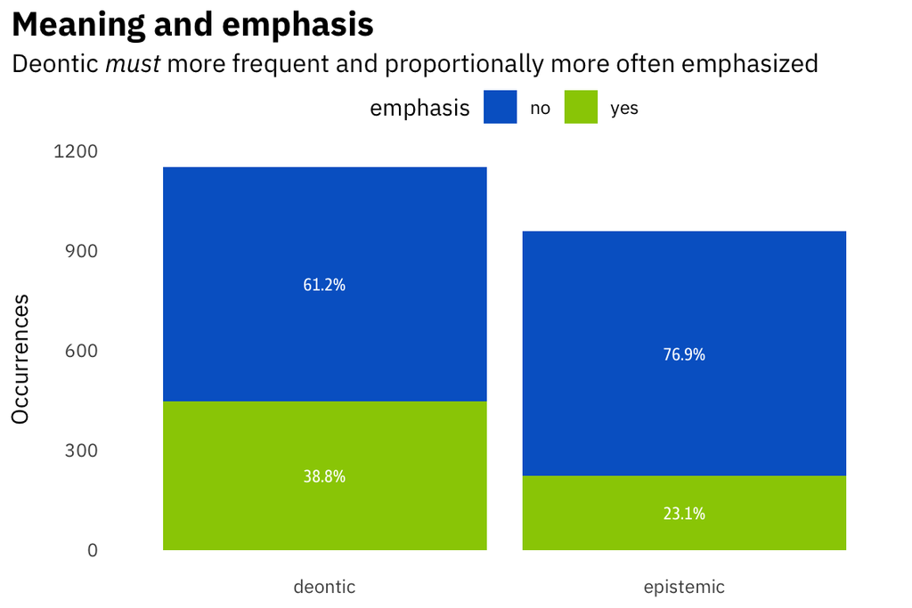

```r
must_tab <- must |>
  group_by(emphasis, meaning) |>
  count() |>
  # get percentages
  group_by(meaning) |>
  mutate(perc = n / sum(n))

ggplot(must_tab, aes(meaning, n, group = emphasis, fill = emphasis, label = perc)) +
  geom_bar(stat = "identity") +
  geom_text(aes(label=sprintf("%1.1f%%", perc*100)), size = 3, position = position_stack(vjust = 0.5), color = "white", family = "Goldman Sans Condensed") +
  labs(
    title = "Meaning and emphasis",
    subtitle = "Deontic *must* more frequent and proportionally more often emphasized",
    y = "Occurrences", x = NULL
    ) +
  scale_fill_manual(values = c(PB, PG))
```

The effect of emphasis on duration can clearly be seen in this violin plot: *must* uses which are emphasized (green) are overall longer than those who are not (blue). This holds for both *deotic* and *epistemic* uses:

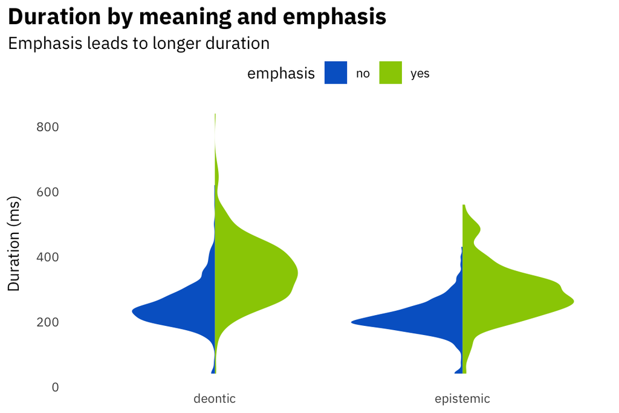

```r
ggplot(must, aes(meaning, dur * 1000, fill = emphasis)) +
  geom_violinhalf(
    data = must |> filter(emphasis == "yes"),
    color = NA
    ) +
  geom_violinhalf(
    data = must |> filter(emphasis == "no"),
    color = NA,
    flip = TRUE
    ) +
  labs(
    title = "Duration by meaning and emphasis",
    subtitle = "Emphasis leads to longer duration",
    y = "Duration (ms)", x = NULL
    ) +
  scale_fill_manual(values = c(PB, PG))
```

### Duration, meaning & speech rate

The combination of these factors can also be visualized as follows:

- deontic *must* (left) is generally longer that epistemic *must* (right) - dots cluster higher on the left
- faster-paced contexts are characterized by shorter word duration: negative correlation left to right
- emphasized uses (green) are generally longer than non-emphasized ones (blue)

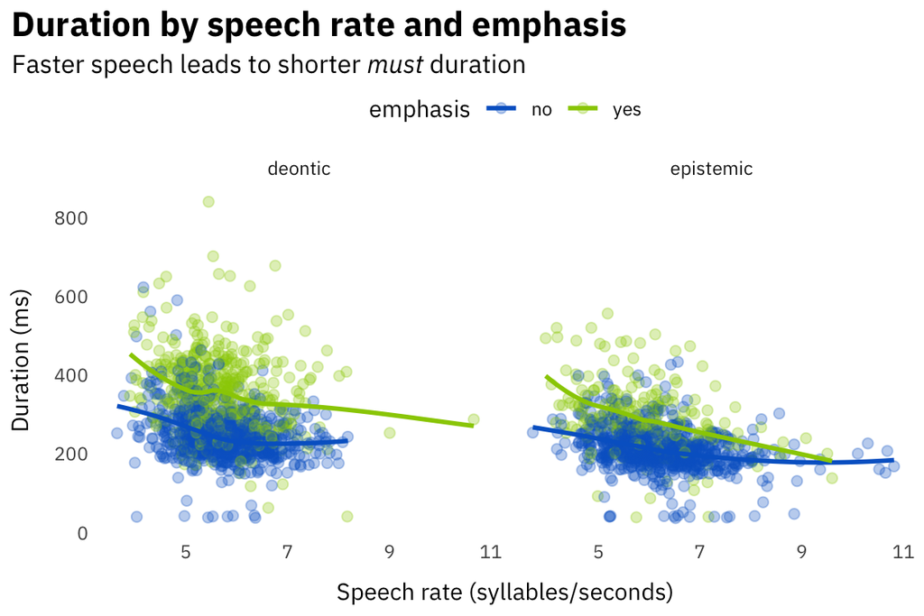

```r
ggplot(must,
       aes(sr, dur * 1000, group = emphasis, color = emphasis)) +
  geom_jitter(size = 2, alpha = 0.3) +
  geom_smooth(se = FALSE) +
  labs(title = "Duration by speech rate and emphasis",
       subtitle = "Faster speech leads to shorter *must* duration",
       x = "Speech rate (syllables/seconds)",
       y = "Duration (ms)") +
  scale_color_manual(values = c(PB, PG)) +
  facet_wrap(~meaning)
```

### …and transitional probability?

If the word that follows *must* occurs often in that position, we also see an effect - greater probability leads to short *must* duration:

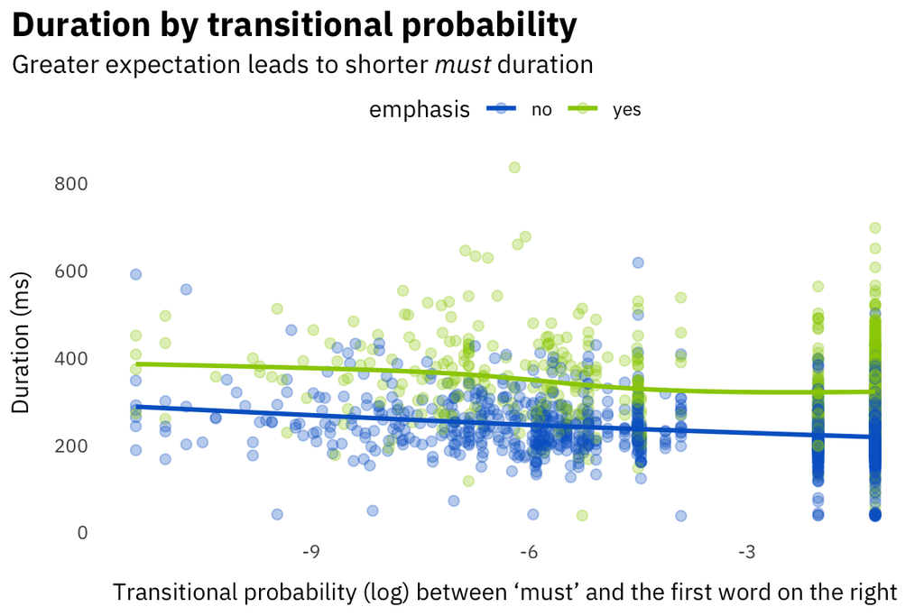

```r
must |>
  # first filter the 'must + R1' combinations where no transitional probability exists:
  filter(!is.na(m_r1_tp_fw)) |>
  ggplot(aes(log(m_r1_tp_fw), dur * 1000, group = emphasis, color = emphasis)) +
  geom_jitter(size = 2, alpha = 0.3) +
  geom_smooth(se = FALSE) +
  labs(title = "Duration by transitional probability",
       subtitle = "Greater expectation leads to shorter *must* duration",
       x = "Transitional probability (log) between 'must' and the first word on the right",
       y = "Duration (ms)") +
  scale_color_manual(values = c(PB, PG))
```

## Regression model

In situations with multiple influencing factors, we can or should use a regression model to test whether the correlation between an outcome (here: duration) and a factor of interest (here: meaning) is independent of all the other variables that also show the same effect. In other words, we need to ‘control’ for the other factors before drawing conclusions.

We can fit a linear model. The picture is overall quite more complicated and the data a little stubborn (as is often the case with language data…), but for illustration purposes, it will suffice for now - and the overal conclusions remain valid even if we throw more robust statistical modelling at that data.

```r
must_lm <- must |>
  rename(duration = dur, speech_rate = sr, trans_prob = m_r1_tp_fw) |>
  select(duration, meaning, emphasis, speech_rate, trans_prob)

lm(log(duration) ~ meaning + speech_rate + emphasis + trans_prob, data = must_lm) |>
  #lm(log(dur) ~ meaning + sr + emphasis + log(m_r1_tp_fw), data = must) %>%
  broom::tidy() %>%
  kable(digits = 3, caption = "Outcome for predictors of simple linear predicting must duration")
```

Outcome for predictors of simple linear predicting must duration

| term | estimate | std.error | statistic | p.value |
| --- | --- | --- | --- | --- |
| (Intercept) | -0.891 | 0.044 | -20.473 | 0.000 |
| meaningepistemic | -0.121 | 0.014 | -8.409 | 0.000 |
| speech_rate | -0.089 | 0.007 | -12.230 | 0.000 |
| emphasisyes | 0.324 | 0.014 | 22.808 | 0.000 |
| trans_prob | -0.163 | 0.053 | -3.085 | 0.002 |

We should be careful to read too much from the data, as mentioned above. But what we *can* read from the `estimate` column is that all predictors with a positive estimate, or “coefficient”, lead to *longer* word duration (`emphasis`) and those with a negative coefficient lead to *shorter* word duration (`meaning` if epistemic, `speech_rate` and `trans_prob`).

We must not read much into numerical differences between the estimates as the predictors are on different scales. We would need to transform the data accordingly, but we’ll leave that for another day.

## Conclusions

Thus, from this model and the data we currently have, we can conclude that the different meanings of *must* indeed show substantial phonetic differences:

- Deontic *must* is substantially longer
- Deontic *must* is also subject to more emphasis (in this data)
- Meaning is a significant factor for word duration

## References

Gahl, Susanne. 2008. *Time* and *thyme* are not homophones: The effect of lemma frequency on word durations in spontaneous speech, *Language* 84: 474-496. 10.1353/lan.0.0035

[^1]: Gahl, Susanne. 2008. Time and thyme are not homophones: The effect of lemma frequency on word durations in spontaneous speech. Language 84(3). 474–496. https://doi.org/10.1353/lan.0.0035. Lohmann, Arne. 2018. Time and thyme are NOT homophones: A closer look at Gahl’s work on the lemma-frequency effect, including a reanalysis. Language 94(2). e180–e190. https://doi.org/10.1353/lan.2018.0032